# TrackView Module

Justin Finkle

7/25/2016

# 1 Gviz Trackview Module

## 1.1 Intro

This vignette describes the implementation of the trackview module for displaying local coverage, annotation, and epigenome information. The main functionality is in coordinating Gviz tracks to most appropriately match the available data.

## 1.2 Load Data

First we load data in the appropriate format. Nearly all the functions require data to be in the form of Genomic Ranges obects. The following objects are required for any trackview to be displayed:

1. A list of coverage files for each sample that will be displayed
   - Currently only bigWig files are supported, but this can easily be changed

We use the samples/pairs tables as in gChipseq, and then pull a few sample files for reference

```r
info_dir <- "~/CARROLL_PR/data/"
s_file <- paste(info_dir, "samples.txt", sep='')
p_file <- paste(info_dir, "pairs.txt", sep='')
fi <- chipVis::get_chip_file_info(s_file, p_file)
org <- "human"
genome <- "GRCh38"

# Pre loading the transcript data makes for faster interactive plots.
# it won't matter much here though
txdb <- Homo.sapiens
tx_data <- load_tx_data(txdb)


# Get the coverage files
input <- fi[2, 'Sample.Control']
input_idx <- which(fi$Sample.Name==input)
idx <- c(2:4, input_idx)

# The last file is the Input, so we'll adjust the name for brevity
shortened_names <- c(fi[idx[1:length(idx)-1], "Sample.Name"], "Input")

# Get scaling factors based on library size
sf <- chipVis::get_scaling_factor(fi[idx,])/1000000
sf
```

```
##                 SRR2000673 SRR2000674 SRR2000675 T47D_Input_Full_Media_3hr
## Total             15.21503   14.93836  12.661649                 105.33146
## Uniquely mapped   12.11391   11.79006   9.911046                  85.04137
```

```r
sf <- sf[2,]
```

2. The target range to display, which can be made in one of two ways:
   - Calculated automatically if a gene symbol is supplied
   - Specified directly by the user

```r
# This range should correspond to NRIP1
range.gene <- chipVis::get_view_range(txdb, "NRIP1", keytype="SYMBOL")
seqlevelsStyle(range.gene) <- "NCBI"
# range.gene <- chipVis::get_view_range(chr = 21, start=14865936, end=14961235)
range.gene <- chipVis::extend_grange(range.gene, extend=100000)
```

With this in hand we can get the annotation and the coverage from the files provided for the specified range. The exon data can be either a dataframe or GRanges object, and the coverage is a GRangesList object.

```r
# Get the exon list. We specifically ignore introns because Gviz calculates them on its own
exon_data <- get_tx_annotation(db_object = txdb, range = range.gene,
                               tx_data = tx_data, no_introns=TRUE)
cvg <- chipVis::get_coverage_in_range(fi[idx, "File.bw"], range.gene,
                                      shortened_names, cvg_scaling = sf)

cvg
```

```
## GRangesList object of length 4:
## $SRR2000673
## GRanges object with 2864 ranges and 1 metadata column:
##          seqnames               ranges strand   |              score
##             <Rle>            <IRanges>  <Rle>   |          <numeric>
##      [1]       21 [16233556, 16233830]      *   | 0.0825497504644868
##      [2]       21 [16233831, 16234162]      *   |                  0
##      [3]       21 [16234163, 16234216]      *   | 0.0825497504644868
##      [4]       21 [16234217, 16234226]      *   |  0.165099500928974
##      [5]       21 [16234227, 16234239]      *   |  0.330199001857947
##      ...      ...                  ...    ... ...                ...
##   [2860]       21 [16537999, 16538009]      *   | 0.0825497504644868
##   [2861]       21 [16538010, 16538014]      *   |  0.165099500928974
##   [2862]       21 [16538015, 16538202]      *   |   0.24764925139346
##   [2863]       21 [16538203, 16538230]      *   |  0.330199001857947
##   [2864]       21 [16538231, 16538231]      *   |  0.412748752322434
##
## ...
## <3 more elements>
## -------
## seqinfo: 194 sequences from an unspecified genome
```

## 1.3 Plot Track Options

Gviz essentially concatenates many horizontal types of information into a vertical stack for algined genomic display. We’ve curated some of the more important functions to better display a varied range of data.

### 1.3.1 Plot Types

#### 1.3.1.1 Standard Coverage view

Now we can start plotting! This is a standard coverage plot in the region.

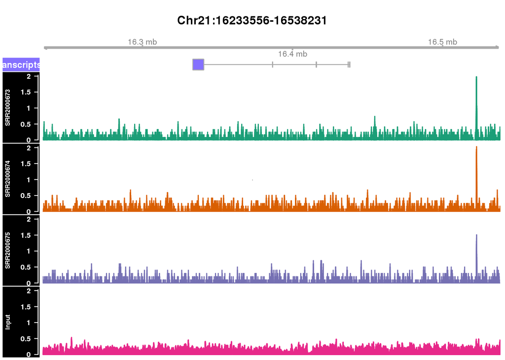

```r
track_info <- chipVis::plot_track_view(cvg_list = cvg, target_range = range.gene,
                              genome=genome, exon_data = exon_data)
```

#### 1.3.1.2 Heatmap view

What if we want to plot more samples? We can easily grab more data and plot. By default, if more than 4 samples are supplied, a heatmap will be used.

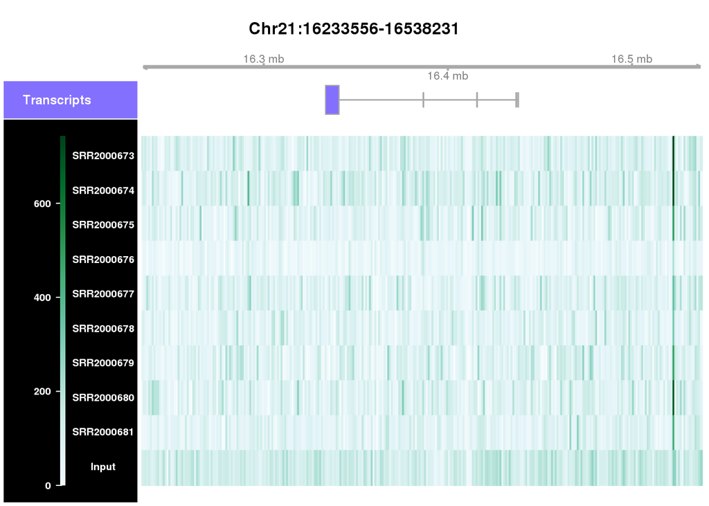

```r
idx <- c(2:10, input_idx)
shortened_names <- c(fi[idx[1:length(idx)-1], "Sample.Name"], "Input")
sf <- chipVis::get_scaling_factor(fi[idx,])/1000000
sf <- sf[2,]
more_cvg <- chipVis::get_coverage_in_range(fi[idx, "File.bw"], range.gene,
                                      shortened_names, cvg_scaling = sf)
track_info <- chipVis::plot_track_view(more_cvg, range.gene, exon_data, genome)
```

#### 1.3.1.3 Plot type

If you are very committed to using a specific type of plot you can use different parameters. It is recommended that you don’t change “hm.thresh”, but instead specify the plot “type”

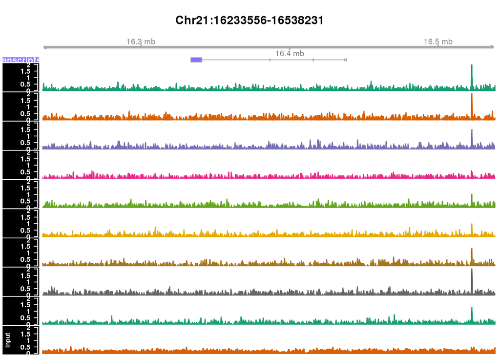

```r
track_info <- chipVis::plot_track_view(more_cvg, range.gene, exon_data, genome,
                                       type='hist')
```

### 1.3.2 Additional Annotations

When plotting tracks we build a big vertical stack that line up with the GenomeAxisTrack. If other data is available it is easy to plot as well. Currently TSS and SNP data is supported.

#### 1.3.2.1 TSS

To save space, the transcript annotations are collapsed by default. Therefore, it may be useful to see annotated TSS. Overall this often results in fewer vertical stacks in the annotation, saving space.

TSS can be determined from TxDb objects, but must be supplied as a GRanges object

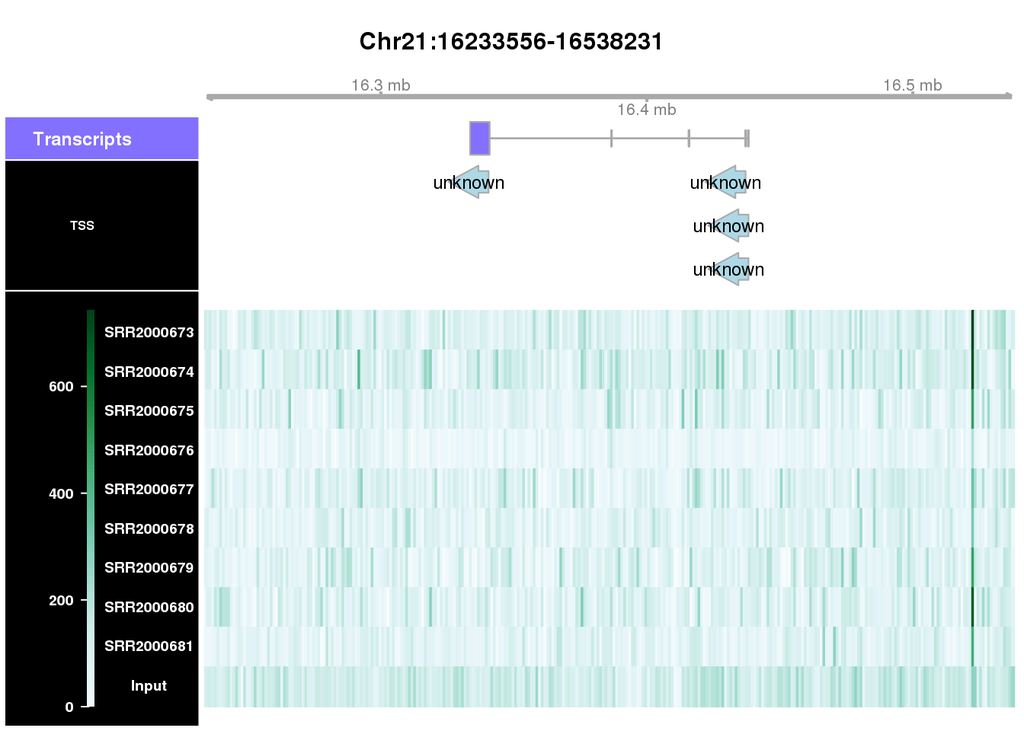

```r
tss_db <- gChipseq::tssFromTxdb(txdb)
track_info <- chipVis::plot_track_view(more_cvg, range.gene, exon_data, genome,
                                       tss_gr = tss_db)
```

#### 1.3.2.2 SNPs

Data is currently from the [GWAS Catalog](https://www.ebi.ac.uk/gwas/). For ease of use it has been made into a GRanges object and saved as an RDS object.

NOTE: Currently the Y-axis labels for the SNP classification may not be correct. However, the stratification and location are accurate.

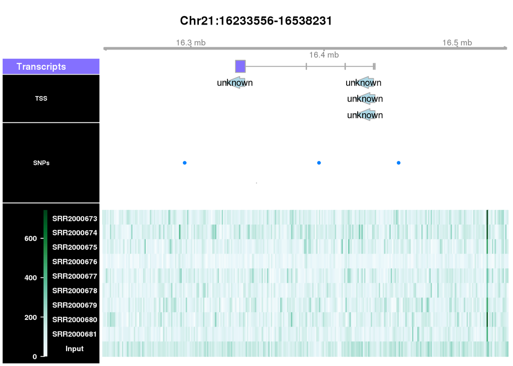

```r
snps <- readRDS("~/workspace/ExternalData/SNP/gwas_catalog_v1.0.1-associations_e84_r2016-07-10.rds")
track_info <- chipVis::plot_track_view(more_cvg, range.gene, exon_data, genome,
                                       tss_gr = tss_db, snp_gr = snps)
```

## 1.4 Display Options

Gviz has a ton of plotting options that are hard to keep track of. We’ve tried to supply logical defaults based on the data. However, most display parameters can be changed.

Nevertheless, Gviz is not great at autosizing text, and it is challenging to provide default values that will work in all cases. Therefore, each track can take a list of keyword arguments (kwargs) to easily adjust the output and precluding modification of the functions.

### 1.4.1 Sizing

Gviz uses relative sizes to plot tracks. Therefore it is easiest to control the size of each track via the plot_kwargs argument. Size values can be any scalar, but fractions summing to 1 are the most straightforward

All tracks can be sized individually via their own track kwargs, however this is not recommended.

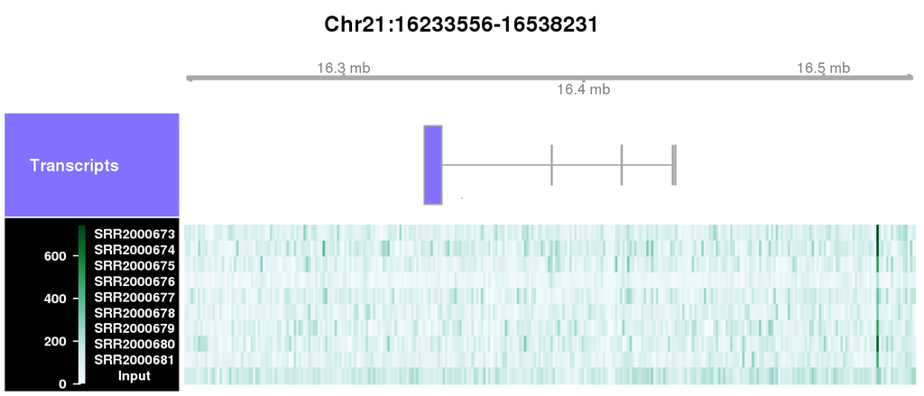

```r
sizes <- c(0.2, 0.3, 0.5)
track_info <- chipVis::plot_track_view(more_cvg, range.gene, exon_data, genome,
                                       plot_kwargs = list(sizes=sizes))
```

### 1.4.2 Data Tracks

#### 1.4.2.1 Grouping

Grouping is a particularly useful feature of Gviz. A quick example of this functionality is to group samples that have similar conditions. Gviz will automatically color the data in the heatmap. All we have to do is supply a grouping vector that matches the order of the samples

Notice that the background panel color is also changed. The kwargs give you all the flexibility available in Gviz!

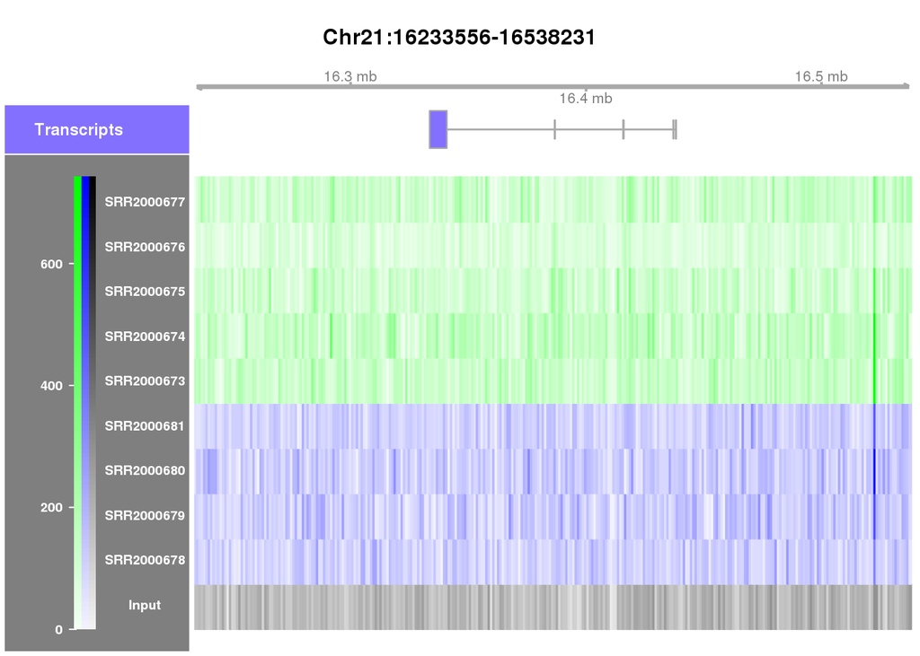

```r
# These are made up groups for the example
grouping <- c(rep('WT', 5), rep('KO', 4), 'Input')

# For whatever reason, the colors are in reverse order from the groups. Probably
# a bug in Gviz somewhere
colors <- c('black', 'blue', 'green')
dkwargs <- list(groups=grouping, col=colors, background.title='gray50')

# Then we just supply it as a list of kwargs
track_info <- chipVis::plot_track_view(more_cvg, range.gene, exon_data, genome,
                                       dtrack_kwargs = dkwargs)
```

#### 1.4.2.2 Averages

We can even use the same groupings to compute averages, and at the same time override the plot type to make a line plot with confidence intervals. All that is required is a vector specifying the types to plot. All plotted types will be overlaid.

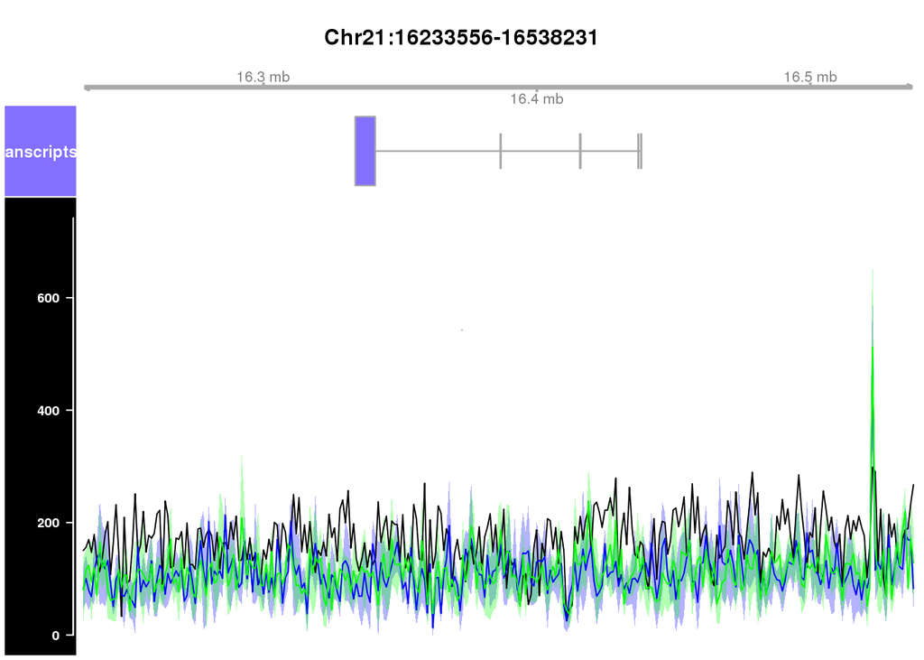

```r
dkwargs <- list(groups=grouping, col=colors, type=c('a', 'confint'))

# Then we just supply it as a list of kwargs
track_info <- chipVis::plot_track_view(more_cvg, range.gene, exon_data, genome,
                                       dtrack_kwargs = dkwargs)
```

#### 1.4.2.3 Coverage Options

All kwargs get applied globally to the datatrack. This isn’t an issue for heatmap, but for the histogram plot is is, because each sample is plotted independently. Some flexibility is provided via the optional arguments color, bg.title, ymax, and sync:

- Color: str or vector specifying the colors for each data track
- bg.title: str or vector specifying the colors for each track panel
- ymax: vector of max values for the each data track
- sync: logical for whether to sync the ymax for all data tracks

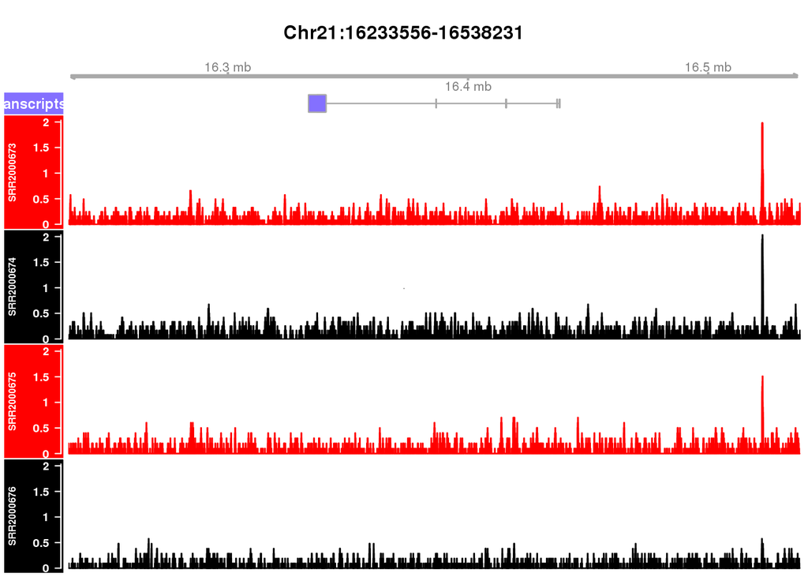

```r
# Colors match the samples and will be repeated to equal the number of samples used
colors <- c('red', 'black')
# Then we just supply it as a list of kwargs
track_info <- chipVis::plot_track_view(more_cvg[1:4], range.gene, exon_data, genome,
                                       colors = colors, bg_title = colors)
```

### 1.4.3 Annotation Track

By default the transcripts are condensed to save space. If you’d like to view them all this is a very easy fix.

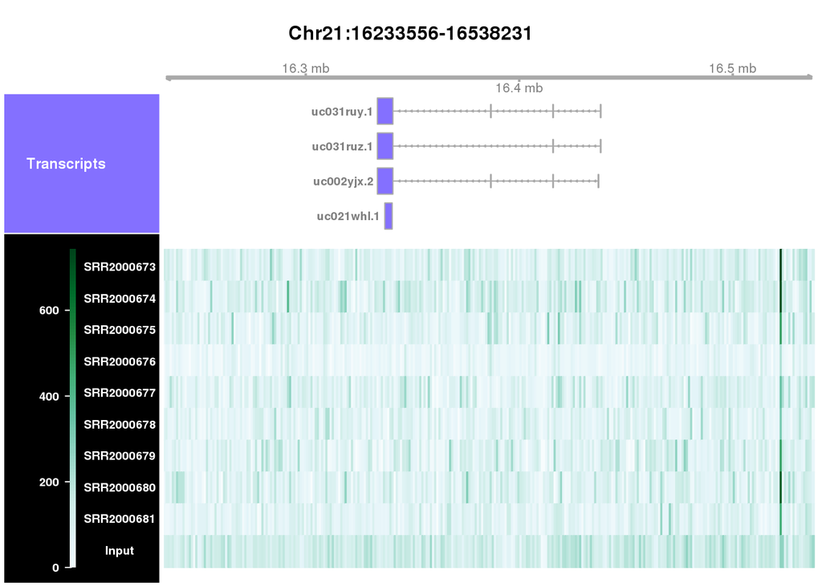

```r
# Then we just supply it as a list of kwargs
track_info <- chipVis::plot_track_view(more_cvg, range.gene, exon_data, genome,
                                       grtrack_kwargs = list(stacking='squish'))
```